# 检测基因流示例-应用模拟数据

## **2.3 QuIBL**

S1：准备QuIBL数据文件,指定输入的基因树文件、测试分支长度分布数量、似然值变化停止阈值、外群、输出文件等参数；

```r
sink(file="inputfile.txt")
cat(paste0("[Input]","\n"))
cat(paste0("treefile: genetree.tres","\n"))
cat(paste0("numdistributions: 2","\n"))
cat(paste0("likelihoodthresh: 0.01","\n"))
cat(paste0("numsteps: 10","\n"))
cat(paste0("gradascentscalar: 0.5","\n"))
cat(paste0("totaloutgroup: E","\n"))
cat(paste0("multiproc: True","\n"))
cat(paste0("maxcores:1000","\n"))
cat(paste0("[Output]","\n"))
cat(paste0("OutputPath: result.csv","\n"))
sink()
```

S2：执行QuIBL方法，命令为：“python QuIBL.py inputfile.txt”；

S3：分析QuIBL结果。读入结果文件，计算两种分布模型的BIC值差deltaBIC，根据其结果判断仅存在ILS或同时存在ILS与Introgression。

```r
result<-read.csv("result.csv")
result$deltaBIC<-result$BIC2Dist-result$BIC1Dist
result$type<-""
type=c("concordant","discordant1","discordant2")
t<-drop.tip(sptree,"E")
out<-t$tip.label[min(t$edge[t$edge[,1]==length(t$tip.label)+1,2])]
temp<-seq(from=1,to=nrow(result),by=3)
w<-which(result$outgroup[temp[1]:(temp[1]+2)]==out)
result$type[temp[1]:(temp[1]+2)][w]<-type[1]
result$type[temp[1]:(temp[1]+2)][-w]<-type[2:3]
result$result<-ifelse(result$type=="concordant" & result$deltaBIC < -30 ,"Concordant",ifelse(result$deltaBIC< -30 & result$type!="concordant","ILS+Introgression",ifelse(result$type=="concordant" & result$deltaBIC > -30,"Extreme ILS","ILS")))
result
```

```
##   triplet outgroup C1       C2   mixprop1  mixprop2 lambda2Dist lambda1Dist
## 1   A_B_C        A  0 3.144553 0.07295113 0.9270489  0.01447052  0.04523736
## 2   A_B_C        B  0 3.786348 0.03365159 0.9663484  0.07410281  0.27492387
## 3   A_B_C        C  0 2.218411 0.01364282 0.9863572  0.08399392  0.20813639
##     BIC2Dist   BIC1Dist count    deltaBIC        type            result
## 1  -43.35183  -39.61406    10   -3.737773 discordant1               ILS
## 2 -588.02144 -191.64900   339 -396.372444 discordant2 ILS+Introgression
## 3 -893.33633 -507.63317   451 -385.703165  concordant        Concordant
```

结果显示B为外群的三元拓扑为ILS+Introgression。

# **三、PhyloNet**

S1：准备PhyloNet输入文件,包括含有基因树的树模块和执行PhyloNet的命令模块；

```r
gts<-readLines("800locus_iqtree_treefile.tres")
gts<-paste0("Tree gt",1:800,"=",gts)
#write file
sink("phylonet_InferNetwork_MPL_input.nex")
cat(paste0("#NEXUS","\n","\n"))
cat(paste0("BEGIN TREES;","\n","\n"))
cat(paste0(gts,"\n"))
cat(paste0("\n","END;","\n"))
cat(paste0("\n", "BEGIN PHYLONET;","\n","\n"))
cat("InferNetwork_MPL (all) 1 -pl 20 -di resultOutputFile phylonet_InferNetwork_MPL_out.tres;")
cat(paste0("\n","\n","END;","\n"))
sink()
```

S2：执行PhyloNet命令：“java -jar PhyloNet_3.8.2.jar phylonet_InferNetwork_MPL_input.nex”

S3: 读取PhyloNet结果，用R可视化似然值最大的网络树。

```r
result<-readLines("phylonet_InferNetwork_MPL_out.tres")
network<-result[3]
network
```

```
## [1] "(((B:1.0,(A:1.0)#H1:1.0::0.6011773749687261):2.5688535784776247,((#H1:1.0::0.3988226250312738,C:1.0):5.927336212055351,D:1.0):1.322065351009499):0.12697359216218265,E:1.0);"
```

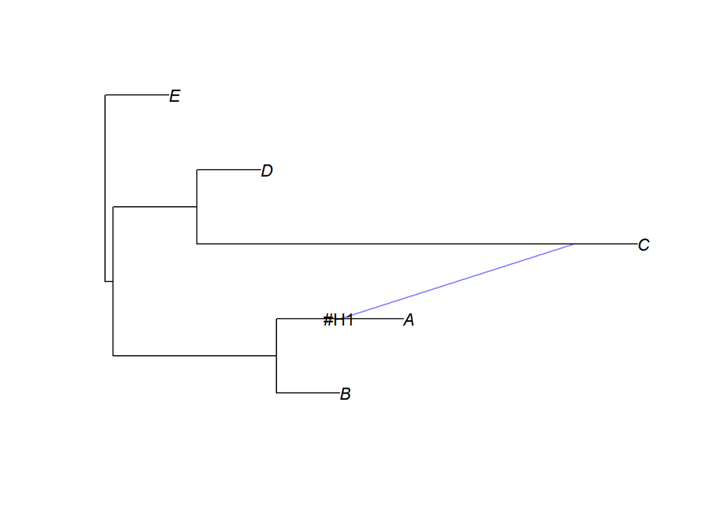

```r
net<-read.evonet(text=network)
plot(net)
nodelabels(text=net$node.label,frame = "none")
```

结果显示A与C存在基因流，通过网络树Netwick格式可以看出两者间的遗传比例为40%。